# Project Report

Group Members: Sagar Patel(sbp170003) Karan Kapadia(kxk170017) Esha Punjabi(EHP170000)

# Introduction

## Ethereum:

The Ethereum project was created in July 2015 based on the proposal by Vitalik Buterin. Like Bitcoin, Ethereum is a distributed public blockchain network. In the Ethereum blockchain, instead of mining for bitcoin, miners work to earn Ether, a type of crypto token that fuels the network. Beyond a tradeable cryptocurrency, Ether is also used by application developers to pay for transaction fees and services on the Ethereum network. Ethereum blockchain has some extraordinary capabilities. One of them is that you can build smart contracts. It’s kind of what it sounds like. It’s a contract that self-executes, and the contract handles the enforcement, the management, performance, and payment

## ERC20:

ERC20 is a protocol standard that defines certain rules and standards for issuing tokens on Ethereum’s network. In ‘ERC20’, ERC stands for Ethereum Request For Comments and 20 stands for a unique ID number to distinguish this standard from others. To put it in layman terms, if you include certain functions in the token’s smart contract, you are ERC20 compliant. If you don’t include the mandatory functions, you are not ERC20. ERC 20 tokens don’t have their dedicated blockchain and thrive on Ethereum’s blockchain instead. This is the reason why, when you send ERC20 tokens, you are required to have some Ethereum as GAS.

## About Primary Token:

In this project, we selected EOS token as our primary token. EOS tokens are ERC-20 compatible tokens distributed on the Ethereum blockchain pursuant to a related ERC-20 smart contract (the “EOS Tokens”). Recently, EOS has been so successful that it is on the verge of becoming its own blockchain technology like ethereum. We are going to mine the EOS token data using statistical methods. EOS token has 18 decimals so it has total of 10^18 sub units. The no of transactions the data has is 2326723. The Token consists of datapoints in the following format : fromNodeID toNodeID unixTime tokenAmount.

## Project Question1:

In this, we will be using EOS token to model the plotting distribution of how many times a user buys, sells a token. Find the best distribution fit by estimating the distribution parameters.

## 1.Selection of Token:

### Token Name:

### 2.Loading the Data

```r
eos_token <- read.table("~/Desktop/R/Ethereum token graphs/networkeosTX.txt", quote="\"", comment.char="", header = FALSE)
colnames(eos_token) <- c("fromnodeID", "tonodeId", "unixtime", "tokenamount")
eos_frame<-data.frame(eos_token)
head(eos_frame)
```

```
##   fromnodeID tonodeId   unixtime  tokenamount
## 1    3116916    40044 1524611245 1.158800e+19
## 2    3116917    40044 1524611245 7.400000e+18
## 3    3101799  3116918 1524611245 7.500000e+19
## 4    3091415   145709 1524611245 1.352972e+20
## 5    3116919    40190 1524611290 1.999913e+20
## 6    3098886  3116920 1524611290 2.000000e+20
```

### 3.Data Preprocessing-Removing Outliers

In Data Preprocessing, we need to filter out all the data that has tokenAmount that is greater then total amount of Token. So, Total amount of Token = total supply * number of decimals. For eos token in etheruem, it has total supply of 10^9 and subunits of 18 decimal.

Total amount of eos_token=(10^9*10^18).

### 3.1 find outliers

```r
outlierdata<-eos_frame[which (eos_frame$tokenamount > (10^27)),]
```

Total Number of Outliers:

```r
message("Total number of outliers:",length(outlierdata$tokenamount))
```

```
## Total number of outliers:13571
```

### 3.2 Number Of users involved in outlier Transactions

```r
users<-c(outlierdata$fromnodeID,outlierdata$tonodeId)
uniqueusers<-unique(users)
message("Total number Of users involved in outlier Transactions:",length(uniqueusers))
```

```
## Total number Of users involved in outlier Transactions:3645
```

### 3.3 Remove outliers

```r
datawithoutoutlier<-eos_frame[which (eos_frame$tokenamount < (10^27)),]
```

Data without Outliers:

```r
message("Amount of data without outliers:",length(datawithoutoutlier$tokenamount))
```

```
## Amount of data without outliers:2313151
```

## 4. Find the Distribution of Buyers

### 4.1 Find the frequency of buyers

```r
frequency_table<-table(datawithoutoutlier["tonodeId"])
freq<-as.data.frame(frequency_table)
colnames(freq)<-c("BuyerId","Frequency")
head(freq)
```

```
##   BuyerId Frequency
## 1       5    118322
## 2       6        84
## 3       7      1448
## 4       8      4105
## 5      13         1
## 6      15         4
```

### 4.2 Find the frequency of number of buys of a token

```r
frequency_buyers<-table(freq$Frequency)
freq<-as.data.frame(frequency_table)
colnames(freq)<-c("NoOfBuys","FrequencyofNoOfBuys")
head(freq)
```

```
##   NoOfBuys FrequencyofNoOfBuys
## 1        5              118322
## 2        6                  84
## 3        7                1448
## 4        8                4105
## 5       13                   1
## 6       15                   4
```

### 4.3 Plot the bar plot for frequency of number of buys of a token(x=buys,y=frequency)

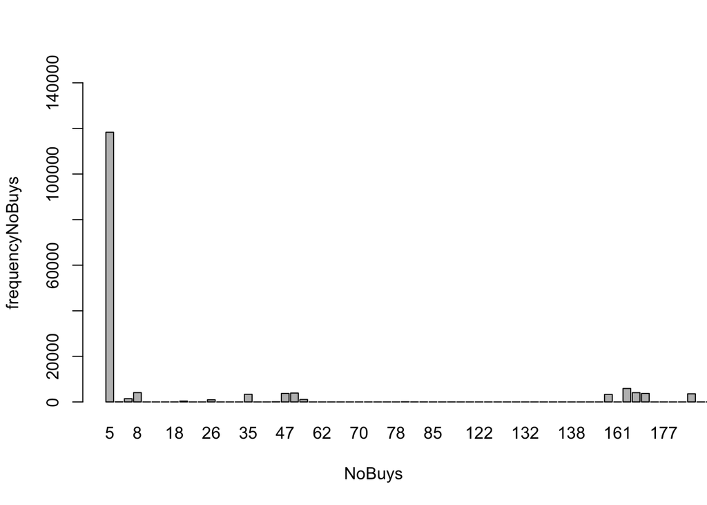

```r
barplot(freq$FrequencyofNoOfBuys,names.arg = freq$NoOfBuys,ylab = "frequencyNoBuys", xlab = "NoBuys", xlim = c(0,70),ylim = c(0,140000))
```

### 4.4 Fit Distribution. For this, we are using ‘fitdistrplus’ library.

Loading required package: MASS,survival,npsurv,lsei

```r
library(fitdistrplus)
message("mean of frequency of number of buys is ", mean(freq$FrequencyofNoOfBuys))
```

```
## mean of frequency of number of buys is 3.20076021741056
```

```r
fit <- fitdist(freq$FrequencyofNoOfBuys, "pois", method="mle")
fit
```

```
## Fitting of the distribution ' pois ' by maximum likelihood
## Parameters:
##        estimate Std. Error
## lambda  3.20076 0.00210451
```

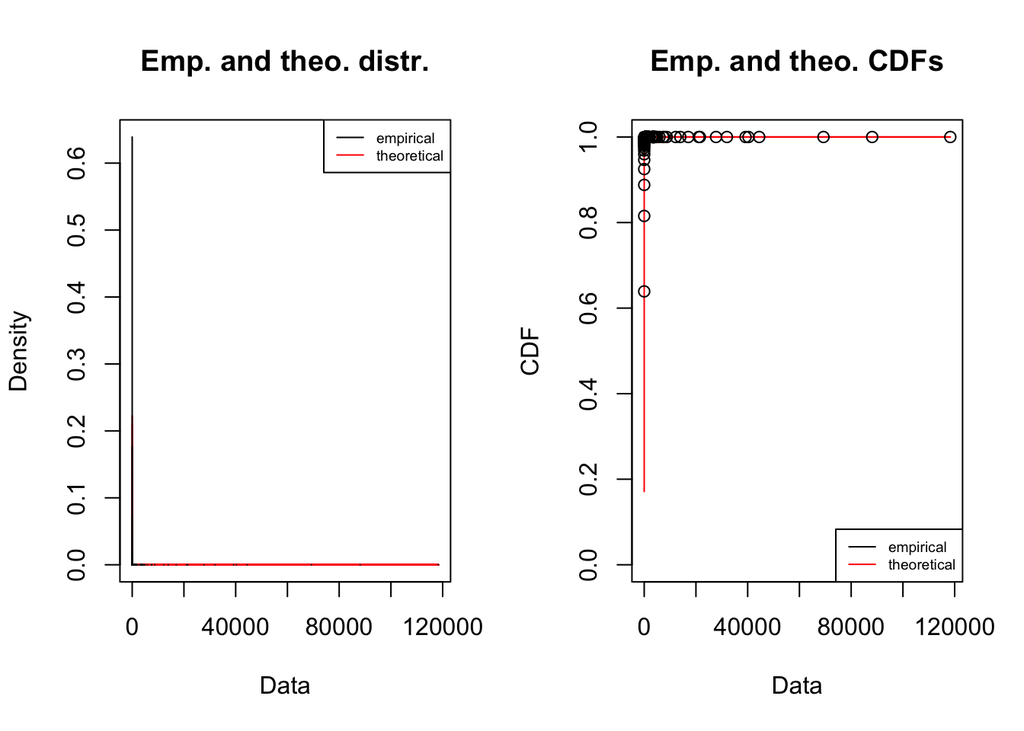

```r
plot(fit)
```

```r
summary(fit)
```

```
## Fitting of the distribution ' pois ' by maximum likelihood
## Parameters :
##        estimate Std. Error
## lambda  3.20076 0.00210451
## Loglikelihood:  -7774808   AIC:  15549618   BIC:  15549630
```